# Covid Unemployment Project

Lynn Chou, Tammy Hu, Anna Shi, Jonathan Que Trinh

## Introduction

We are interested in “Unemployment during the Covid pandemic” because we want to find out how it the pandemic has contributed to unemployment and if there are certain groups of people who are more unemployed than others during the pandemic.

## Summary

The world has been greatly impacted by the Coronavirus. The US experienced the most cases and deaths in the entire world. The state with the most deaths is New York. Coincidentally, the state that experienced the most Black deaths is also New York. In the US, minority communities experienced highest rates of death. On a daily average, the minority community experiences 322.637931 deaths. The Black community have especially been impacted by the pandemic. Their community experiences a average daily death count of 206.9971264. Minority groups make up 21.2826527% of deaths in the US, with the Black community making up 66.178878% of the minority death population. In general, minority groups have been the most vulnerable during the pandemic, being more exposed to the virus and experience deaths at higher rates than white communities.

| Race | total_change |
| --- | --- |
| African-American | -9971075 |
| Hispanic | -12195967 |
| Other | -2273962 |
| White | -33146501 |

For the COVID Unemployment data, we renamed some columns for better readability and calculated the summary of the total change in the number of job gains or loss by each four race, that being African-American, Hispanic, Other, and White. We thought that this might give us an insight as to which racial communities are most impacted and have lost the most jobs due to the the pandemic. We found that each of the four experienced loss of job during the pandemic, with the race with the highest impact is White, but proportionally to their populations, Hispanic and African-Americans are more impacted by the loss of unemployment during the pandemic.

## White with COVID outside of total white population

```
[1] 0.141428
```

## African-Americans with COVID out of the total African American population

```
[1] 0.2261015
```

## Hispanics with COVID out of the total Hispanics population

```
[1] 0.2012536
```

## Aggregate Table Script: Cumulative Cases by Race

| State | Date | White | Black | Hispanic/Latino | Asian | American Indian/Alaska Native | Native Hawaiian/Pacific Islander | Multiracial | Other | Unknown |
| --- | --- | --- | --- | --- | --- | --- | --- | --- | --- | --- |
| AK | 2020-04-12 | NA | NA | NA | NA | NA | NA | NA | NA | NA |
| AK | 2020-04-15 | 133 | 4 | NA | 25 | 13 | 3 | 6 | 3 | 106 |
| AK | 2020-04-19 | 167 | 7 | NA | 33 | 14 | 4 | 10 | 5 | 79 |
| AK | 2020-04-22 | 184 | 7 | NA | 37 | 18 | 6 | 10 | 7 | 66 |
| AK | 2020-04-26 | 190 | 7 | NA | 41 | 18 | 6 | 0 | 9 | 70 |
| AK | 2020-04-29 | 206 | 7 | NA | 43 | 19 | 8 | 10 | 9 | 53 |
| AK | 2020-05-03 | 216 | 8 | NA | 44 | 22 | 10 | 11 | 9 | 48 |
| AK | 2020-05-06 | 225 | 9 | NA | 44 | 22 | 13 | 11 | 9 | 39 |
| AK | 2020-05-10 | 238 | 9 | NA | 45 | 24 | 13 | 12 | 10 | 28 |
| AK | 2020-05-13 | 250 | 9 | NA | 45 | 24 | 13 | 14 | 12 | 16 |
| AK | 2020-05-17 | 257 | 9 | NA | 45 | 29 | 13 | 15 | 12 | 16 |
| AK | 2020-05-20 | 261 | 9 | NA | 46 | 31 | 14 | 14 | 12 | 15 |
| AK | 2020-05-24 | 263 | 10 | NA | 46 | 33 | 14 | 15 | 12 | 15 |
| AK | 2020-05-27 | 264 | 10 | NA | 46 | 36 | 14 | 16 | 12 | 14 |
| AK | 2020-05-31 | 274 | 13 | NA | 46 | 41 | 15 | 16 | 12 | 43 |
| AK | 2020-06-03 | 301 | 14 | NA | 49 | 54 | 15 | 16 | 12 | 44 |
| AK | 2020-06-07 | 327 | 15 | NA | 52 | 59 | 16 | 21 | 12 | 42 |
| AK | 2020-06-10 | 349 | 16 | NA | 57 | 69 | 16 | 22 | 12 | 52 |
| AK | 2020-06-14 | 378 | 17 | NA | 58 | 71 | 17 | 24 | 15 | 81 |
| AK | 2020-06-17 | 398 | 17 | NA | 59 | 78 | 17 | 24 | 17 | 86 |
| AK | 2020-06-21 | 430 | 19 | NA | 58 | 83 | 18 | 26 | 16 | 105 |
| AK | 2020-06-24 | 461 | 22 | NA | 58 | 89 | 20 | 28 | 17 | 97 |
| AK | 2020-06-28 | 489 | 23 | NA | 60 | 101 | 25 | 32 | 17 | 136 |
| AK | 2020-07-01 | 508 | 24 | NA | 60 | 113 | 27 | 32 | 20 | 194 |
| AK | 2020-07-05 | 541 | 25 | NA | 60 | 131 | 29 | 36 | 22 | 294 |
| AK | 2020-07-08 | 584 | 30 | NA | 61 | 141 | 29 | 40 | 24 | 317 |
| AK | 2020-07-12 | 633 | 35 | NA | 63 | 177 | 39 | 43 | 30 | 459 |
| AK | 2020-07-15 | 672 | 39 | NA | 65 | 204 | 53 | 43 | 36 | 519 |
| AK | 2020-07-19 | 726 | 45 | NA | 67 | 247 | 66 | 53 | 38 | 632 |
| AK | 2020-07-22 | 750 | 49 | NA | 67 | 282 | 76 | 61 | 38 | 809 |

[output cut: 4898 more lines]

For the Covid By Race data, decided to calculate the total cases of covid by each racial group to further determine which racial groups have been most impacted by covid. Based on the table, multiracial groups, Native Americans/Alaska Natives, and Native Hawaiian/Pacific Islanders consistently tested the least positive for covid-19. After May 31, 2020 in WA state, Hispanics, Blacks, and Unknown races consistently tested more positive than Whites until October 14, where Whites and Unknown races test more positive than Hispanics and Blacks.

## Aggregate Table Script: Rate of Increase in cases by Race

| State | Date | White | Black | Hispanic/Latino | Asian | American Indian/Alaska Native | Native Hawaiian/Pacific Islander | Multiracial | Other | Unknown |
| --- | --- | --- | --- | --- | --- | --- | --- | --- | --- | --- |
| AK | 2020-04-12 | NA | NA | NA | NA | NA | NA | NA | NA | NA |
| AK | 2020-04-15 | NA | NA | NA | NA | NA | NA | NA | NA | NA |
| AK | 2020-04-19 | 25.6 | 75.0 | NA | 32.0 | 7.7 | 33.3 | 66.7 | 66.7 | -25.5 |
| AK | 2020-04-22 | 10.2 | 0.0 | NA | 12.1 | 28.6 | 50.0 | 0.0 | 40.0 | -16.5 |
| AK | 2020-04-26 | 3.3 | 0.0 | NA | 10.8 | 0.0 | 0.0 | -100.0 | 28.6 | 6.1 |
| AK | 2020-04-29 | 8.4 | 0.0 | NA | 4.9 | 5.6 | 33.3 | Inf | 0.0 | -24.3 |
| AK | 2020-05-03 | 4.9 | 14.3 | NA | 2.3 | 15.8 | 25.0 | 10.0 | 0.0 | -9.4 |
| AK | 2020-05-06 | 4.2 | 12.5 | NA | 0.0 | 0.0 | 30.0 | 0.0 | 0.0 | -18.8 |
| AK | 2020-05-10 | 5.8 | 0.0 | NA | 2.3 | 9.1 | 0.0 | 9.1 | 11.1 | -28.2 |
| AK | 2020-05-13 | 5.0 | 0.0 | NA | 0.0 | 0.0 | 0.0 | 16.7 | 20.0 | -42.9 |
| AK | 2020-05-17 | 2.8 | 0.0 | NA | 0.0 | 20.8 | 0.0 | 7.1 | 0.0 | 0.0 |
| AK | 2020-05-20 | 1.6 | 0.0 | NA | 2.2 | 6.9 | 7.7 | -6.7 | 0.0 | -6.2 |
| AK | 2020-05-24 | 0.8 | 11.1 | NA | 0.0 | 6.5 | 0.0 | 7.1 | 0.0 | 0.0 |
| AK | 2020-05-27 | 0.4 | 0.0 | NA | 0.0 | 9.1 | 0.0 | 6.7 | 0.0 | -6.7 |
| AK | 2020-05-31 | 3.8 | 30.0 | NA | 0.0 | 13.9 | 7.1 | 0.0 | 0.0 | 207.1 |
| AK | 2020-06-03 | 9.9 | 7.7 | NA | 6.5 | 31.7 | 0.0 | 0.0 | 0.0 | 2.3 |
| AK | 2020-06-07 | 8.6 | 7.1 | NA | 6.1 | 9.3 | 6.7 | 31.2 | 0.0 | -4.5 |
| AK | 2020-06-10 | 6.7 | 6.7 | NA | 9.6 | 16.9 | 0.0 | 4.8 | 0.0 | 23.8 |
| AK | 2020-06-14 | 8.3 | 6.2 | NA | 1.8 | 2.9 | 6.2 | 9.1 | 25.0 | 55.8 |
| AK | 2020-06-17 | 5.3 | 0.0 | NA | 1.7 | 9.9 | 0.0 | 0.0 | 13.3 | 6.2 |
| AK | 2020-06-21 | 8.0 | 11.8 | NA | -1.7 | 6.4 | 5.9 | 8.3 | -5.9 | 22.1 |
| AK | 2020-06-24 | 7.2 | 15.8 | NA | 0.0 | 7.2 | 11.1 | 7.7 | 6.2 | -7.6 |
| AK | 2020-06-28 | 6.1 | 4.5 | NA | 3.4 | 13.5 | 25.0 | 14.3 | 0.0 | 40.2 |
| AK | 2020-07-01 | 3.9 | 4.3 | NA | 0.0 | 11.9 | 8.0 | 0.0 | 17.6 | 42.6 |
| AK | 2020-07-05 | 6.5 | 4.2 | NA | 0.0 | 15.9 | 7.4 | 12.5 | 10.0 | 51.5 |
| AK | 2020-07-08 | 7.9 | 20.0 | NA | 1.7 | 7.6 | 0.0 | 11.1 | 9.1 | 7.8 |
| AK | 2020-07-12 | 8.4 | 16.7 | NA | 3.3 | 25.5 | 34.5 | 7.5 | 25.0 | 44.8 |
| AK | 2020-07-15 | 6.2 | 11.4 | NA | 3.2 | 15.3 | 35.9 | 0.0 | 20.0 | 13.1 |
| AK | 2020-07-19 | 8.0 | 15.4 | NA | 3.1 | 21.1 | 24.5 | 23.3 | 5.6 | 21.8 |
| AK | 2020-07-22 | 3.3 | 8.9 | NA | 0.0 | 14.2 | 15.2 | 15.1 | 0.0 | 28.0 |

[output cut: 4898 more lines]

## Chart 1

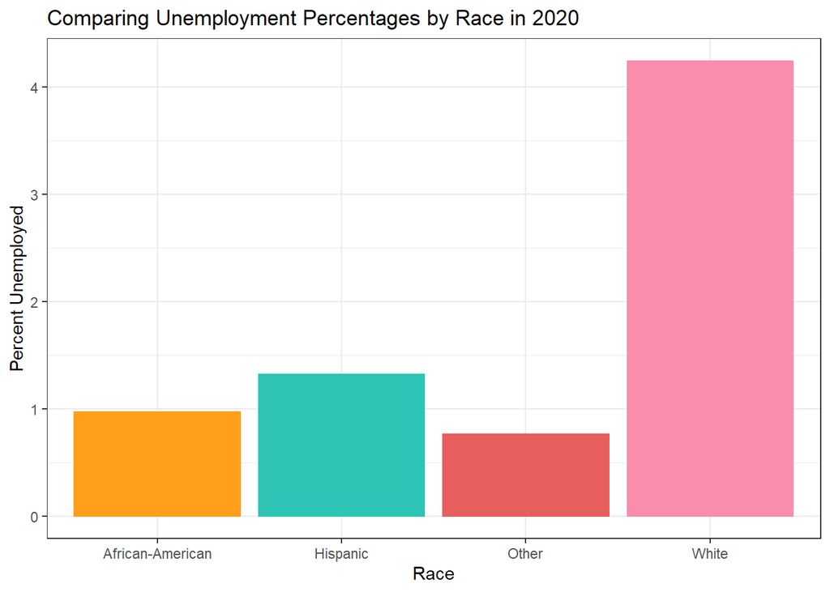

## Chart 2

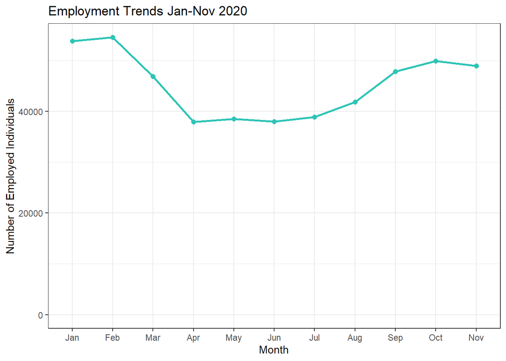

This chart was intended to show the trends of employed individuals across a year by month. The observed data shows a significant dip during months march through may, slowly rising in numbers going into fall season.

## Chart 3

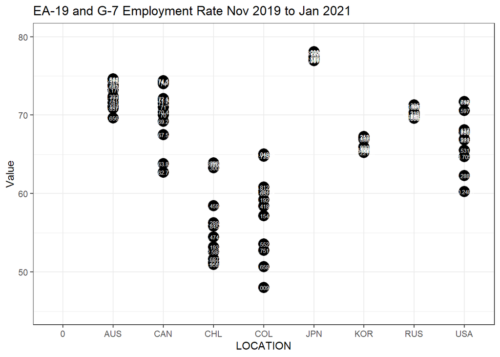